# Technology mediation in child sexual exploitation and abuse in Africa and Asia

CSEA Modelling script

Author

Ghai et al.

# Preface

In this script, we examine whether age, gender, and degree of urbanisation are associated with children’s self-reported experiences of technology-facilitated CSEA. Analyses were not preregistered and are presented as post hoc, exploratory. The data are cross-sectional, so findings are associational. We fit survey-weighted Bayesian logistic models and report results on both the log-odds scale (posterior means with 95% credible intervals) and the response scale as average marginal effects and predicted probabilities.

1. **Demographic model** (age/gender): We first modelled age–gender patterns in predicting technology-facilitated CSEA using two Bayesian logistic regressions that allow countries to differ in both baseline risk and age/gender gradients.
2. **Degree of urbanisation model** (urban, rural and peri-urban): We next estimate two survey-weighted Bayesian logistic models to assess how degree of urbanisation relates to technology-facilitated CSEA, accounting for age, gender, and between-country heterogeneity.

```r
# Load packages
library(tidyverse)
library(rlang)
library(brms)
library(cmdstanr)
library(posterior)
library(loo)
library(emmeans)
library(marginaleffects)
library(ggdist)
library(viridis)
library(RColorBrewer)
library(scales)
library(flextable)
library(officer)
library(knitr)
library(kableExtra)
library(gtsummary)
library(png)
library(dplyr)
library(bayestestR)

knitr::opts_chunk$set(dev = "png")

# Modelling: run brms with cmdstanr maybe with threading
dir.create("models", FALSE)
options(
  brms.backend = "cmdstanr",
  mc.cores = min(parallel::detectCores(), 8),
  brms.threads = parallel::detectCores() %/% 4
)
# Make plots pretty
theme_set(
  theme_linedraw() +
    theme(panel.grid = element_blank())
)
# Output options
opts_chunk$set(
  eval = TRUE,
  cache = TRUE,
  warning = FALSE,
  error = FALSE,
  message = FALSE,
  echo = knitr::is_html_output()
)
options(digits = 2)

# HMC iterations
ITER <- 2000
```

We load the cleaned data here

We select only the relevant variables for demographic predictors of technology-facilitated CSEA.

```r
d_victim <- d_victim %>%
  select(
    pid = CBU_ID,
    sex,
    age,
    urbanrural,
    COUNTRY,
    wgt_scaled,
    victim,
    starts_with("abuse_")
  )
```

# Demographic Factors Predicting Technology-facilitated CSEA.

## (1) Demographic Model (age/gender)

- Model 1: First (additive) model includes fixed effects for gender and age without a fixed interaction, letting country-specific random terms capture departures from the pooled pattern.
- Model 2: Second (interaction) model adds a global gender×age term to test whether age effects differ systematically by gender after accounting for between-country heterogeneity. Both models use a Bernoulli likelihood with sampling weights (wgt_scaled) and were fit via cmdstanr; compiled objects are saved in models/for reuse.

```r
fit_victim_a <- brm(
  victim | weights(wgt_scaled) ~ sex + age + (sex * age | COUNTRY),
  data = d_victim,
  family = bernoulli(),
  silent = 0,
  backend = "cmdstanr",
  iter = ITER,
  file = "models/brm-victimadd"
)

fit_victim <- brm(
  victim | weights(wgt_scaled) ~ sex * age + (sex * age | COUNTRY),
  data = d_victim,
  family = bernoulli(),
  silent = 0,
  backend = "cmdstanr",
  iter = ITER,
  file = "models/brm-victim"
)
```

## (2) Degree of urbanisation (urban, rural and peri-urban) model

- Model 1: fit_urban - Random intercepts by country; fixed effects for degree of urbanisation, gender, and age. Tests average urban–peri-urban–rural contrasts after adjusting for age and gender, providing average-country effects (country baselines vary; slopes do not).
- Model 2: fit_urban2 - Extends Model 1 with flexible age-by-gender terms (age curve with gender interaction) to produce age- and gender-specific risk curves and urban–peri-urban–rural contrasts adjusted for those profiles.

```r
fit_urban <- brm(
  victim | weights(wgt_scaled) ~ sex + age + urbanrural + (1 | COUNTRY),
  data = d_victim,
  family = bernoulli(),
  silent = 0,
  backend = "cmdstanr",
  iter = ITER,
  file = "models/brm-urban"
)

fit_urban2 <- brm(
  victim | weights(wgt_scaled) ~ sex * age + urbanrural + (sex * age  | COUNTRY),
  data = d_victim,
  family = bernoulli(),
  silent = 0,
  backend = "cmdstanr",
  iter = ITER,
  file = "models/brm-urban2",
)
```

### Results

#### Population-level Effects for All Models Predicting Technology-facilitated CSEA

We first focus on effects for the average country. This table shows numerical summaries (mean, standard deviation, and 95% credible intervals, PD (probability of direction) for population-level parameters.

```r
# Define a function for posterior draws
summarise_draws_pop0 <- function(fit, variable = c("b_", "sd_", "cor_")) {
  fit %>%
    as_draws_df(variable = variable, regex = TRUE) %>%
    summarise_draws(
      mean = mean,
      sd = sd,
      q2.5 = ~quantile(.x, 0.025),
      q97.5 = ~quantile(.x, 0.975),
      pd    = ~max(mean(.x > 0), mean(.x < 0))
    )
}


# Recode variable
labels0 <- c(
  "b_sex1" = "Girls (vs Boys)",
  "b_age" = "Age",
  "b_sex1:age" = "Age:Gender interaction",
  "b_urbanruralRural" = "Rural",
  "b_urbanruralUrban" = "Urban"
)

## fit_victim
summarise_draws_pop0(fit_victim, variable = "b_") %>%
       filter(variable != "b_Intercept") %>%
  mutate(
  variable = dplyr::recode(variable, !!!labels0),
  pd = if_else(
    pd == 1,
    "> 99.9%",
    percent(pd, accuracy = 0.01)
  )
  ) %>%
  kable(col.names = c("Parameter", "Mean", "SD", "2.5% CI", "97.5% CI", "PD > 0)"))
```

Results of the demographic factor model predicting technology-facilitated CSEA (interaction model)

| Parameter | Mean | SD | 2.5% CI | 97.5% CI | PD > 0) |
| --- | --- | --- | --- | --- | --- |
| Girls (vs Boys) | -0.01 | 0.11 | -0.22 | 0.20 | 53.55% |
| Age | 0.18 | 0.04 | 0.10 | 0.26 | > 99.9% |
| Age:Gender interaction | 0.09 | 0.04 | 0.01 | 0.17 | 98.50% |

```r
## fit_victim_a
summarise_draws_pop0(fit_victim_a, variable = "b_") %>%
       filter(variable != "b_Intercept") %>%
  mutate(
  variable = dplyr::recode(variable, !!!labels0),
  pd = if_else(
    pd == 1,
    "> 99.9%",
    percent(pd, accuracy = 0.01)
  )
  ) %>%
  kable(col.names = c("Parameter", "Mean", "SD", "2.5% CI", "97.5% CI", "PD > 0)"))
```

Table 1: Results of the demographic factor model predicting technology-facilitated CSEA (additive model)

| Parameter | Mean | SD | 2.5% CI | 97.5% CI | PD > 0) |
| --- | --- | --- | --- | --- | --- |
| Girls (vs Boys) | 0.00 | 0.12 | -0.25 | 0.23 | 51.42% |
| Age | 0.18 | 0.05 | 0.09 | 0.28 | 99.90% |

```r
## fit_urban
summarise_draws_pop0(fit_urban, variable = "b_") %>%
       filter(variable != "b_Intercept") %>%
  mutate(
  variable = dplyr::recode(variable, !!!labels0),
  pd = if_else(
    pd == 1,
    "> 99.9%",
    percent(pd, accuracy = 0.01)
  )
  ) %>%
  kable(col.names = c("Parameter", "Mean", "SD", "2.5% CI", "97.5% CI", "PD > 0)"))
```

Results of degree of urbanisation model 1 predicting technology-facilitated CSEA

| Parameter | Mean | SD | 2.5% CI | 97.5% CI | PD > 0) |
| --- | --- | --- | --- | --- | --- |
| Girls (vs Boys) | 0.02 | 0.05 | -0.08 | 0.12 | 67.25% |
| Age | 0.17 | 0.02 | 0.14 | 0.21 | > 99.9% |
| Rural | -0.32 | 0.09 | -0.49 | -0.15 | 99.92% |
| Urban | -0.14 | 0.09 | -0.32 | 0.04 | 94.48% |

```r
## fit_urban2
summarise_draws_pop0(fit_urban2, variable = "b_") %>%
       filter(variable != "b_Intercept") %>%
  mutate(
  variable = dplyr::recode(variable, !!!labels0),
  pd = if_else(
    pd == 1,
    "> 99.9%",
    percent(pd, accuracy = 0.01)
  )
  ) %>%
  kable(col.names = c("Parameter", "Mean", "SD", "2.5% CI", "97.5% CI", "PD > 0)"))
```

Results of degree of urbanisation model 2 predicting technology-facilitated CSEA

| Parameter | Mean | SD | 2.5% CI | 97.5% CI | PD > 0) |
| --- | --- | --- | --- | --- | --- |
| Girls (vs Boys) | -0.01 | 0.10 | -0.23 | 0.19 | 55.05% |
| Age | 0.18 | 0.04 | 0.10 | 0.26 | 99.98% |
| Rural | -0.32 | 0.09 | -0.49 | -0.14 | > 99.9% |
| Urban | -0.14 | 0.09 | -0.32 | 0.05 | 93.05% |
| Age:Gender interaction | 0.08 | 0.04 | 0.00 | 0.16 | 97.42% |

We next plot the probability of technology-facilitated CSEA conditional on age and sex for the average country

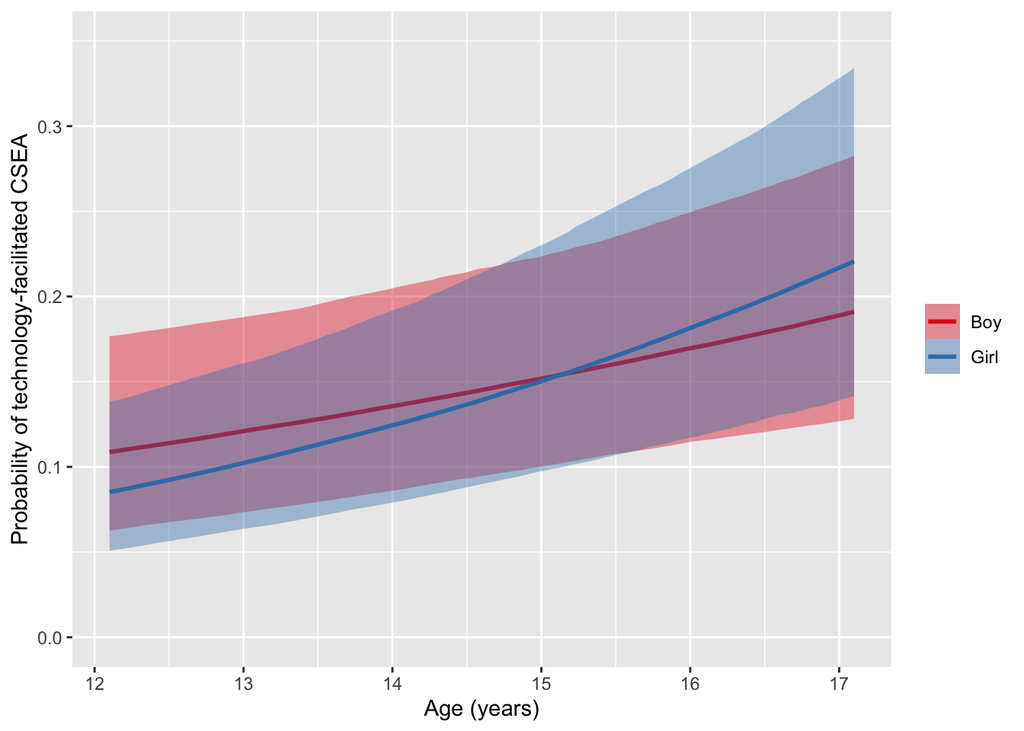

Association between age and probablity of technology-facilitated CSEA for boys and girls for the average country in the sample.

```r
# Function to extract brms_conditional_effects
ce_ggplot <- function(brms_conditional_effects) {
  brms_conditional_effects %>%
    plot(plot = FALSE) %>%
    .[[1]]
}
# Get conditional effects for the age:gender interaction term
p_victim_pop <- conditional_effects(
  fit_victim,
  "age:sex"
) %>%
  ce_ggplot()

# Plot
p_victim_pop +
  scale_color_brewer(
    palette = "Set1",
    aesthetics = c("color", "fill")
  ) +
  scale_y_continuous(
    "Probability of technology-facilitated CSEA",
    limits = c(0, 0.35)
  ) +
  scale_x_continuous(
    "Age (years)",
    labels = ~ . + 15
  ) +
  theme(
    legend.title = element_blank()
  )
```

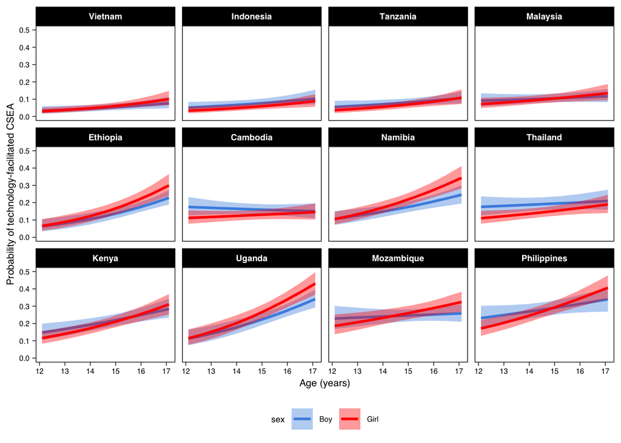

Figure 1: Association between age and probablity of technology-facilitated CSEA victimhood for boys and girls and each country. The countries are sorted from least average technology-facilitated CSEA to greatest.

```r
# Generate conditional effects by country
p_victim_country <- conditional_effects(
  fit_victim,
  "age:sex",
  conditions = distinct(d_victim, COUNTRY),
  re_formula = NULL,
  resolution = 9
) %>% ce_ggplot()

# Plot
p_victim_country <- p_victim_country +
  scale_color_manual(
    values = c("Girl" = "red", "Boy" = "#4A90E2"),
    aesthetics = "color"
  ) +
  scale_fill_manual(
    values = c("Girl" = "red", "Boy" = "#4A90E2"),
    aesthetics = "fill"
  ) +
  scale_y_continuous(
    "Probability of technology-facilitated CSEA",
    limits = c(0, 0.5)
  ) +
  scale_x_continuous(
    "Age (years)",
    labels = ~ . + 15
  ) +
  facet_wrap("COUNTRY") +
  theme(
    axis.title.x     = element_text(size = 8, family = "sans"),
    axis.title.y     = element_text(size = 8, family = "sans"),
    axis.text.x      = element_text(size = 6, family = "sans"),
    axis.text.y      = element_text(size = 6, family = "sans"),
    legend.position  = "bottom",
    legend.title     = element_text(size = 7, family = "sans"),
    legend.text      = element_text(size = 6, family = "sans"),
    strip.background = element_rect(fill = "black", colour = "black"),
    strip.text       = element_text(face = "bold", size = 7,
                                    colour = "white", family = "sans")
  )

# Ordering panels by average level of technology-facilitated CSEA
p_victim_country$data <- p_victim_country$data %>%
  mutate(
    COUNTRY = fct_reorder(COUNTRY, estimate__)
         )
p_victim_c <- p_victim_country
p_victim_c

ggsave(
  "Figure2.pdf",
  p_victim_c +
    theme(
      axis.title   = element_text(size = 7, family = "sans"),
      axis.text    = element_text(size = 6, family = "sans"),
      strip.text   = element_text(face = "bold", size = 7,
                                  colour = "white", family = "sans"),
      legend.text  = element_text(size = 7, family = "sans"),
      legend.title = element_text(size = 7, family = "sans")
    ),
  width  = 18,
  height = 17,
  units  = "cm",
  dpi    = 600
)
```

## Predicted probabilities for the age/gender model

We now build a grid for ages 12 and 17 across all countries by gender and compute response-scale predictions with 95% CIs

```r
# Prediction grid setup
age_offset <- 15
ages_target <- c(12, 17)
sex_levels <- levels(d_victim$sex)
INCLUDE_RE <- TRUE

# Build prediction grid
grid <- expand.grid(
  COUNTRY = sort(unique(d_victim$COUNTRY)),
  sex     = factor(sex_levels, levels = sex_levels),
  Age     = ages_target
)

# Center age around offset
grid$age <- grid$Age - age_offset

# Predict probabilities on response scale with 95% credible intervals
fit_out <- fitted(
  fit_victim,
  newdata    = grid[, c("COUNTRY", "sex", "age")],
  re_formula = if (INCLUDE_RE) NULL else NA,
  scale      = "response",
  summary    = TRUE,
  probs      = c(0.025, 0.975),
  seed = 123
)

# Combine grid info with predictions
victim_pred <- cbind(
  grid[, c("COUNTRY", "Age", "sex")],
  as.data.frame(fit_out)
)

victim_pred <- victim_pred %>%
  rename(
    Country      = COUNTRY,
    Sex          = sex,
    `Lower Bound` = Q2.5,
    `Upper Bound` = Q97.5
  )

# Round numeric columns to 3 decimal places
victim_pred$Estimate      <- round(victim_pred$Estimate, 3)
victim_pred$`Lower Bound` <- round(victim_pred$`Lower Bound`, 3)
victim_pred$`Upper Bound` <- round(victim_pred$`Upper Bound`, 3)

# Sort by Country, Age, Gender
victim_pred <- victim_pred %>%
  arrange(Country, Age, Sex) %>%
  select(Country, Age, Sex, Estimate, `Lower Bound`, `Upper Bound`)

row.names(victim_pred) <- NULL

knitr::kable(
  victim_pred,
  row.names = FALSE,
  col.names = c("Country", "Age", "Sex", "Estimate", "Lower Bound", "Upper Bound")
) %>%
  kableExtra::kable_styling(
    bootstrap_options = c("striped", "hover", "condensed"),
    full_width = FALSE
  )
```

| Country | Age | Sex | Estimate | Lower Bound | Upper Bound |
| --- | --- | --- | --- | --- | --- |
| Cambodia | 12 | Boy | 0.18 | 0.12 | 0.23 |
| Cambodia | 12 | Girl | 0.11 | 0.08 | 0.16 |
| Cambodia | 17 | Boy | 0.15 | 0.11 | 0.20 |
| Cambodia | 17 | Girl | 0.15 | 0.10 | 0.19 |
| Ethiopia | 12 | Boy | 0.06 | 0.03 | 0.10 |
| Ethiopia | 12 | Girl | 0.06 | 0.04 | 0.10 |
| Ethiopia | 17 | Boy | 0.22 | 0.19 | 0.26 |
| Ethiopia | 17 | Girl | 0.29 | 0.23 | 0.36 |
| Indonesia | 12 | Boy | 0.05 | 0.03 | 0.08 |
| Indonesia | 12 | Girl | 0.03 | 0.02 | 0.06 |
| Indonesia | 17 | Boy | 0.10 | 0.07 | 0.15 |
| Indonesia | 17 | Girl | 0.09 | 0.06 | 0.13 |
| Kenya | 12 | Boy | 0.15 | 0.10 | 0.20 |
| Kenya | 12 | Girl | 0.11 | 0.08 | 0.15 |
| Kenya | 17 | Boy | 0.28 | 0.23 | 0.34 |
| Kenya | 17 | Girl | 0.30 | 0.25 | 0.36 |
| Malaysia | 12 | Boy | 0.09 | 0.06 | 0.14 |
| Malaysia | 12 | Girl | 0.07 | 0.05 | 0.11 |
| Malaysia | 17 | Boy | 0.12 | 0.08 | 0.16 |
| Malaysia | 17 | Girl | 0.14 | 0.09 | 0.18 |
| Mozambique | 12 | Boy | 0.23 | 0.17 | 0.30 |
| Mozambique | 12 | Girl | 0.19 | 0.14 | 0.25 |
| Mozambique | 17 | Boy | 0.26 | 0.21 | 0.31 |
| Mozambique | 17 | Girl | 0.32 | 0.26 | 0.38 |
| Namibia | 12 | Boy | 0.11 | 0.07 | 0.15 |
| Namibia | 12 | Girl | 0.10 | 0.07 | 0.14 |
| Namibia | 17 | Boy | 0.24 | 0.19 | 0.30 |
| Namibia | 17 | Girl | 0.34 | 0.28 | 0.40 |
| Philippines | 12 | Boy | 0.23 | 0.17 | 0.30 |
| Philippines | 12 | Girl | 0.17 | 0.12 | 0.22 |
| Philippines | 17 | Boy | 0.34 | 0.27 | 0.40 |
| Philippines | 17 | Girl | 0.40 | 0.34 | 0.47 |
| Tanzania | 12 | Boy | 0.06 | 0.03 | 0.09 |
| Tanzania | 12 | Girl | 0.04 | 0.02 | 0.06 |
| Tanzania | 17 | Boy | 0.11 | 0.08 | 0.14 |
| Tanzania | 17 | Girl | 0.11 | 0.07 | 0.15 |
| Thailand | 12 | Boy | 0.18 | 0.12 | 0.24 |
| Thailand | 12 | Girl | 0.11 | 0.08 | 0.15 |
| Thailand | 17 | Boy | 0.21 | 0.16 | 0.27 |
| Thailand | 17 | Girl | 0.19 | 0.14 | 0.24 |
| Uganda | 12 | Boy | 0.11 | 0.07 | 0.16 |
| Uganda | 12 | Girl | 0.11 | 0.07 | 0.16 |
| Uganda | 17 | Boy | 0.34 | 0.29 | 0.39 |
| Uganda | 17 | Girl | 0.42 | 0.36 | 0.49 |
| Vietnam | 12 | Boy | 0.03 | 0.02 | 0.06 |
| Vietnam | 12 | Girl | 0.03 | 0.02 | 0.05 |
| Vietnam | 17 | Boy | 0.08 | 0.05 | 0.11 |
| Vietnam | 17 | Girl | 0.10 | 0.06 | 0.14 |

```r
write.csv(
  victim_pred,
  file      = "predicted_victim_probabilities.csv",
  row.names = FALSE
)
```

We now plot the model parameters for each country. Posterior densities of country-specific coefficients (Girl vs Boy, Age, Gender by Age) with a zero reference line. Intervals excluding zero suggest stronger evidence; near-zero centers imply weak/no evidence.

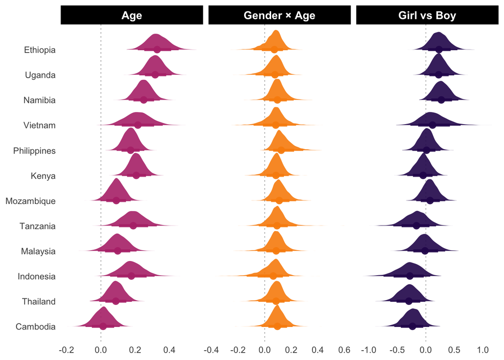

Figure 2: Country-specific age and sex coefficients’ posterior densities.

```r
# Function to extract tidy posterior samples of country-level coefficients
coef_tidy <- function(fit, g = "COUNTRY") {
  coef_country <- coef(fit, summary = FALSE)[[g]]

  purrr::map(
    seq_len(dim(coef_country)[3]),
    ~ coef_country[, , .x] %>%
      posterior::as_draws_df() %>%
      mutate(Parameter = dimnames(coef_country)[[3]][.x]) %>%
      pivot_longer(
        cols = -c(Parameter, starts_with(".")),
        names_to = "Country"
      )
  ) %>%
    bind_rows()
}

coef_df <- coef_tidy(fit_victim) %>%
  filter(Parameter != "Intercept")

# Recode parameter names
coef_df <- coef_df %>%
  mutate(

    Parameter_clean = case_when(
      Parameter %in% c("sexGirl", "sex1") ~ "Girl vs Boy",
      Parameter == "age" ~ "Age",
      Parameter %in% c("sexGirl:age", "sex1:age") ~ "Gender × Age",
      TRUE ~ Parameter
    ),
    Country = forcats::fct_reorder(Country, value, .fun = median)
  )


# Plot
p_victim_country_params <- ggplot(coef_df) +
  aes(
    x = value,
    y = Country,
    fill  = Parameter_clean,
    color = Parameter_clean
  ) +
  geom_vline(
    xintercept = 0,
    linetype = "dotted",
    linewidth = 0.25,
    color = "gray40"
  ) +
  ggdist::stat_slabinterval(
    .width = c(0.8, 0.95),
    normalize = "panels",
    alpha = 0.9
  ) +
  scale_color_manual(
  name = "Parameter",
  values = c(
    "Girl vs Boy"   = "#2C105C",
    "Age"           = "#B63679",
    "Gender × Age"  = "#F98E09"
  )
  ) +
  scale_fill_manual(
  name = "Parameter",
  values = c(
    "Girl vs Boy"   = "#2C105C",
    "Age"           = "#B63679",
    "Gender × Age"  = "#F98E09")
  ) +
  scale_x_continuous("Parameter Value (log-odds scale)") +
  facet_wrap(~ Parameter_clean,
             scales = "free_x",
             ncol = 3
             ) +
  theme_minimal(base_size = 11) +
  theme(
    panel.background = element_blank(),
    panel.grid.major = element_blank(),
    panel.grid.minor = element_blank(),
    axis.title.y = element_blank(),
    axis.title.x = element_blank(),
    legend.position = "none",
    strip.background = element_rect(fill = "black", colour = "black"),
    strip.text = element_text(face = "bold", size = 11, colour = "white")
  )

p_victim_country_params

ggsave(
  filename = "figure_victim_country_parameters.pdf",
  plot = p_victim_country_params,
  width = 10,
  height = 8,
  units = "in",
  dpi = 300
)
```

## Age Contrast (17 vs 12)

```r
# Extract posterior draws
draws <- as_draws_df(fit_victim, variable = "b_", regex = TRUE)

# Overall age contrast (17 vs 12) = b_age * 5
draws <- draws %>%
  mutate(contrast_age_17v12 = b_age * 5)

# Summary
mean_qi(draws$contrast_age_17v12, .width = 0.95)
```

```
     y ymin ymax .width .point .interval
1 0.89 0.48  1.3   0.95   mean        qi
```

```r
p_direction(draws$contrast_age_17v12)
```

```
Probability of Direction

Parameter |   pd
----------------
Posterior | 100%
```

## Equivalence Testing for Sex Differences

```r
# Extract posterior draws for sex
draws <- as_draws_df(fit_victim)
sex_draws <- draws$b_sex1

# Posterior summary
cat("Posterior mean:", round(mean(sex_draws), 3), "\n")
```

```
Posterior mean: -0.008
```

```r
cat("95% CrI:", round(quantile(sex_draws, 0.025), 3),
    round(quantile(sex_draws, 0.975), 3), "\n")
```

```
95% CrI: -0.22 0.2
```

```r
# ROPE equivalence test
rope_lower <- log(0.67)
rope_upper <- log(1.5)
in_rope <- mean(sex_draws >= rope_lower & sex_draws <= rope_upper) * 100
cat(sprintf("ROPE bounds: [%.2f, %.2f]\n", rope_lower, rope_upper))
```

```
ROPE bounds: [-0.40, 0.41]
```

```r
cat(sprintf("%.1f%% of posterior in ROPE\n", in_rope))
```

```
99.7% of posterior in ROPE
```

```r
# Probability of direction
pd <- max(mean(sex_draws > 0), mean(sex_draws < 0)) * 100
cat(sprintf("Probability of direction: %.1f%%\n", pd))
```

```
Probability of direction: 53.5%
```

```r
# Cross-check with fixef
fixef(fit_victim)["sex1", ]
```

```
 Estimate Est.Error      Q2.5     Q97.5
  -0.0083    0.1083   -0.2230    0.2045
```

## Average marginal effects (1) age and gender demographic model

We now look at average marginal effects (age contrasted at one-unit increase and gender Girl/Boy)

```r
 avg_fitvictim <- avg_comparisons(
  fit_victim,
  re_formula = NULL
) %>%
  inferences(method = "delta")
```

```r
 # Format table
ame_victim_tbl <- avg_fitvictim %>%
  as_tibble() %>%
  mutate(
    Label = dplyr::case_when(
      !is.na(contrast) & term == "sex" ~ "Girl vs Boy",
      is.na(contrast) & term == "age"  ~ "Age (+1 year)",
      TRUE ~ ifelse(is.na(contrast), term, paste0(term, ": ", contrast))
    ),
    `Difference (pp)` = sprintf("%.1f", estimate * 100),
    `95% CI`          = sprintf("[%.1f, %.1f]", conf.low * 100, conf.high * 100)
  ) %>%
  select(Label, `Difference (pp)`, `95% CI`)


kable(
  ame_victim_tbl,
  booktabs = TRUE,
  align = c("l","r","r"),
  col.names = c("Contrast", "Difference (pp)", "95% CI")
) %>%
  kable_styling(full_width = FALSE, bootstrap_options = c("striped","hover","condensed"))
```

| Contrast | Difference (pp) | 95% CI |
| --- | --- | --- |
| age: +1 | 2.7 | [2.2, 3.1] |
| Girl vs Boy | 0.8 | [-0.6, 2.0] |

## Leave-one-out cross-validation (victim models)

We compared two Bayesian logistic models of technology-facilitated CSEA: an additive model with main effects for age and sex, and a model that also included the age×sex interaction. For each model we computed leave-one-out cross-validation (LOO) using Pareto-smoothed importance sampling (Vehtari, Gelman, and Gabry, 2017). To avoid recomputation, we save the combined LOO output to disk and reuse it on subsequent runs.

```r
# Compare two Bayesian logistic victim models
path <- file.path("models", "loosvictime.rds")

if (!file.exists(path)) {
  loosvictime <- brms::loo(
    # additive: gender + age
    fit_victim_a,
     # interaction: gender * age
    fit_victim,
    compare = TRUE,
    model_names = c("Additive (gender + age)", "Interaction (gender × age)")
  )
  saveRDS(loosvictime, path)
}
loosvictime <- readRDS(path)

# Compute individual LOO
loo_add <- brms::loo(fit_victim_a)
loo_int <- brms::loo(fit_victim)
```

## Pareto-k vector

Alongside the overall LOO scores, we examined the Pareto-k diagnostics, which quantify how influential each held-out observation is in the PSIS approximation. For each model we report: the number of observations, the largest k value, how many (and what percent) exceed 0.7 (potentially problematic), and how many exceed 1.0 (problematic). This gives a quick sense of whether PSIS-LOO is reliable for these data or whether a more robust validation (e.g., K-fold) might be warranted.

```r
# Extract Pareto-k values to assess PSIS
get_k <- function(loo_obj) {
  as.numeric(loo_obj$diagnostics$pareto_k)
}

# Summarise Pareto-k diagnostics
pareto_summary <- function(k) {
  tibble(
    n          = length(k),
    max_k      = max(k, na.rm = TRUE),
    n_gt_0.7   = sum(k > 0.7, na.rm = TRUE),
    pct_gt_0.7 = round(100 * mean(k > 0.7, na.rm = TRUE), 1),
    n_gt_1.0   = sum(k > 1.0, na.rm = TRUE),
    pct_gt_1.0 = round(100 * mean(k > 1.0, na.rm = TRUE), 1)
  )
}


 # additive model
k_add <- get_k(loo_add)
# interaction model
k_int <- get_k(loo_int)

# Extract Pareto-k values for both models
ps_add <- pareto_summary(k_add) %>% mutate(Model = "Additive (gender + age)")
ps_int <- pareto_summary(k_int) %>% mutate(Model = "Interaction (gender × age)")

pareto_output <- bind_rows(ps_add, ps_int) %>%
  select(Model, n, max_k, n_gt_0.7,  pct_gt_0.7, n_gt_1.0, pct_gt_1.0)

kable(
  pareto_output,
  booktabs = TRUE,
  align = c("l","r","r","r","r","r","r"),
  col.names = c("Model","N","max k","n > 0.7","% > 0.7","n > 1.0","% > 1.0")
) %>%
  kable_styling(full_width = FALSE, bootstrap_options = c("striped","hover","condensed"))
```

| Model | N | max k | n > 0.7 | % > 0.7 | n > 1.0 | % > 1.0 |
| --- | --- | --- | --- | --- | --- | --- |
| Additive (gender + age) | 11912 | 0.39 | 0 | 0 | 0 | 0 |
| Interaction (gender × age) | 11912 | 0.33 | 0 | 0 | 0 | 0 |

## Plot leave-one-out cross-validation

We then contrasted the two models using the difference in expected log predictive density (ΔELPD) from loo_compare. The figure shows ΔELPD for each model with a 1-SE error bar, plotted horizontally for readability and centered on a dashed zero line. Positive values indicate better out-of-sample predictive performance.

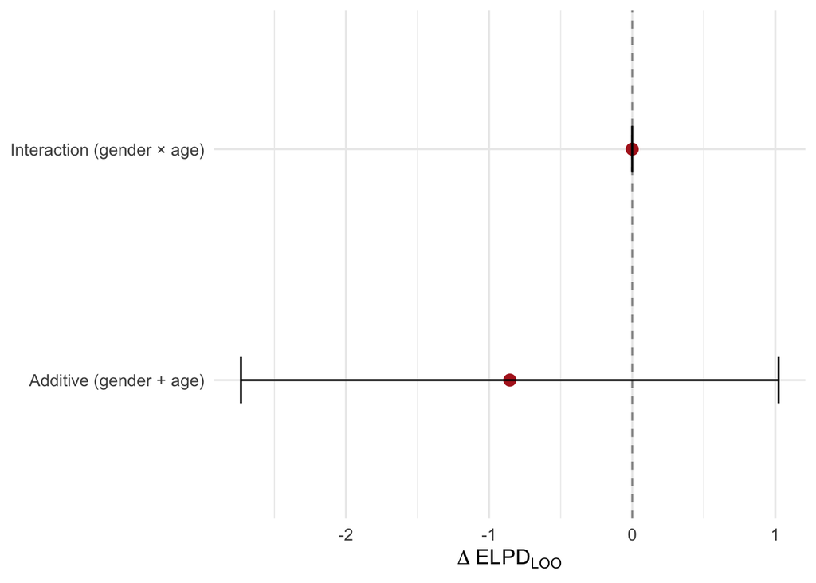

```r
# Plot LOO Comparison
victim_loo <- loo::loo_compare(list(
  "Interaction (gender × age)" = loo_int,
  "Additive (gender + age)"    = loo_add
))

victim_loo_df <- as.data.frame(victim_loo) %>%
  tibble::rownames_to_column("Model")

# ΔELPD plot with standard error bars
plotvictim_loo <- ggplot(victim_loo_df, aes(x = reorder(Model, elpd_diff), y = elpd_diff)) +
  geom_hline(yintercept = 0, linetype = "dashed", color = "grey60") +
  geom_point(size = 3, color = "firebrick") +
  geom_errorbar(
    aes(ymin = elpd_diff - se_diff, ymax = elpd_diff + se_diff),
    width = 0.2
  ) +
  coord_flip() +
  labs(
    x = NULL,
    y = expression(Delta ~ ELPD[LOO])
  ) +
  theme_minimal(base_size = 13)

plotvictim_loo
```

```r
# save figure
ggsave(
filename = "figure_loovic.pdf",
plot     = plotvictim_loo,
width    = 6,
height   = 3.5,
units    = "in",
dpi      = 300
)
```

## Average marginal effects (2) degree of urbanisation

```r
# AMEs
ame_urbanrural <- avg_comparisons(
  fit_urban2,
  variables = list(urbanrural = "pairwise"),
  re_formula = NULL
)
ame_urbanrural
```

```
           Contrast Estimate    2.5 %   97.5 %
 Rural - Peri urban  -0.0442 -0.07115 -0.01902
 Urban - Peri urban  -0.0200 -0.04783  0.00667
 Urban - Rural        0.0241  0.00964  0.03879

Term: urbanrural
Type:  response
Columns: term, contrast, estimate, conf.low, conf.high
```

Each contrast is the average change in predicted prevalence when moving between levels of degree of urbanisation (e.g., Urban vs Rural). Here we holds the model’s covariate distribution constant.

```r
pairwise_urban <- ame_urbanrural  %>%
  as_tibble() %>%
  mutate(
    Comparison = contrast,
    `Difference (pp)` = sprintf("%.1f", estimate * 100),
    `95% CI` = sprintf("[%.1f, %.1f]", conf.low * 100, conf.high * 100)
  ) %>%
  select(Comparison, `Difference (pp)`, `95% CI`)

kable(
  pairwise_urban,
  align = c("l","r","r"),
  col.names = c("Comparison", "Difference (pp)", "95% CI"),
  booktabs = TRUE
) %>%
  kable_styling(full_width = FALSE, bootstrap_options = c("striped","hover","condensed"))
```

| Comparison | Difference (pp) | 95% CI |
| --- | --- | --- |
| Rural - Peri urban | -4.4 | [-7.1, -1.9] |
| Urban - Peri urban | -2.0 | [-4.8, 0.7] |
| Urban - Rural | 2.4 | [1.0, 3.9] |

## Predicted prevalence of degree of urbanisation

We compute COUNTRY × urbanrural marginal predictions using emmeans, which returns prevalence on the response scale with 95% CIs. Estimates are survey-weighted, contrast urban, peri-urban and rural within each countr and are marginalised over covariates in the fitted model (e.g., age, gender).

```r
# build emmeans
rg <- ref_grid(fit_urban2, re_formula = NULL, type = "response")

emm <- emmeans(
  fit_urban2,
  ~ COUNTRY:urbanrural,
  re_formula = NULL,
  type       = "response"
)

df <- as.data.frame(emm)

val_col   <- intersect(c("prob", "response", "emmean", "rate"), names(df))[1]
lower_col <- intersect(c("lower.CL", "asymp.LCL", "lower.HPD"), names(df))[1]
upper_col <- intersect(c("upper.CL", "asymp.UCL", "upper.HPD"), names(df))[1]

# predicted means and intervals
pred_urban_w <- df %>%
  transmute(
    COUNTRY,
    urbanrural = factor(urbanrural, levels = c("Rural","Peri urban","Urban")),
    mean  = .data[[val_col]],
    lower = .data[[lower_col]],
    upper = .data[[upper_col]]
  ) %>%
  arrange(COUNTRY, urbanrural)

# formatted table
pred_urban <- pred_urban_w %>%
  mutate(
    `Mean %`  = scales::percent(mean,  0.1),
    `95% CI` = sprintf("[%s, %s]",
                        scales::percent(lower, 0.1),
                        scales::percent(upper,  0.1))
  ) %>%
  select(
    COUNTRY,
    `Degree of urbanization` = urbanrural,
    `Mean %`, `95% CI`
  )

kable(
  pred_urban,
  booktabs = TRUE,
  align = c("l", "l", "r", "r")
) %>%
  kable_styling(full_width = FALSE) %>%
  collapse_rows(columns = 1, valign = "top")
```

Table 2: Predicted prevalence of technology-facilitated CSEA by degree of urbanisation (Rural, Peri-urban, Urban), with 95% credible intervals.Values are posterior means from the Bayesian regression; intervals are 95% CIs. Panels in the corresponding figure correspond to countries.

| COUNTRY | Degree of urbanization | Mean % | 95% CI |
| --- | --- | --- | --- |
| Cambodia | Rural | 13.4% | [11.3%, 15.7%] |
|  | Peri urban | 17.5% | [14.5%, 21.1%] |
|  | Urban | 15.6% | [13.2%, 18.4%] |
| Ethiopia | Rural | 13.7% | [11.4%, 16.3%] |
|  | Peri urban | 17.9% | [14.2%, 21.5%] |
|  | Urban | 16.0% | [13.2%, 18.9%] |
| Indonesia | Rural | 6.1% | [4.6%, 7.6%] |
|  | Peri urban | 8.1% | [6.1%, 10.4%] |
|  | Urban | 7.2% | [5.5%, 9.0%] |
| Kenya | Rural | 20.3% | [17.8%, 22.9%] |
|  | Peri urban | 25.9% | [22.0%, 30.4%] |
|  | Urban | 23.4% | [20.6%, 26.6%] |
| Malaysia | Rural | 9.1% | [7.3%, 10.9%] |
|  | Peri urban | 12.1% | [9.7%, 14.7%] |
|  | Urban | 10.7% | [8.8%, 12.9%] |
| Mozambique | Rural | 23.4% | [20.8%, 26.2%] |
|  | Peri urban | 29.6% | [25.3%, 34.0%] |
|  | Urban | 26.8% | [23.7%, 29.7%] |
| Namibia | Rural | 18.0% | [15.7%, 20.6%] |
|  | Peri urban | 23.2% | [19.4%, 27.3%] |
|  | Urban | 20.8% | [18.2%, 23.6%] |
| Philippines | Rural | 27.0% | [24.0%, 29.9%] |
|  | Peri urban | 33.7% | [29.0%, 38.4%] |
|  | Urban | 30.7% | [27.3%, 34.0%] |
| Tanzania | Rural | 6.9% | [5.3%, 8.5%] |
|  | Peri urban | 9.2% | [7.1%, 11.9%] |
|  | Urban | 8.2% | [6.4%, 10.0%] |
| Thailand | Rural | 15.9% | [13.6%, 18.2%] |
|  | Peri urban | 20.7% | [17.0%, 24.4%] |
|  | Urban | 18.5% | [15.7%, 21.2%] |
| Uganda | Rural | 23.1% | [20.5%, 26.1%] |
|  | Peri urban | 29.1% | [24.5%, 33.7%] |
|  | Urban | 26.4% | [23.1%, 29.7%] |
| Vietnam | Rural | 5.3% | [4.1%, 6.7%] |
|  | Peri urban | 7.1% | [5.3%, 9.3%] |
|  | Urban | 6.2% | [4.7%, 7.9%] |

## Plotting predicted prevalence by degree of urbanisation

For each country, we compare predicted prevalence across rural, peri-urban, urban with 95% credible intervals, adjusted for demographics (and survey weights via the fitted Bayesian model), to show cross-country heterogeneity in urbanisation gradients.

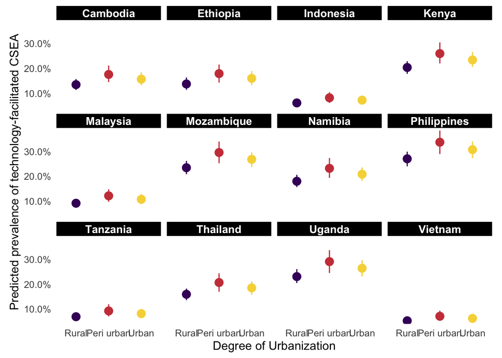

Figure 3: Predicted prevalence of technology-facilitated CSEA by degree of urbanisation (Rural, Peri-urban, Urban), with 95% credible intervals. Points indicate posterior means and vertical bars the 95% CI from the Bayesian regression; panels correspond to countries.

```r
# plot urban rural diff
urbanrural_plot <- ggplot(
  pred_urban_w,
  aes(x = urbanrural, y = mean, ymin = lower, ymax = upper, color = urbanrural)
) +
  geom_pointrange(size = 0.7) +
  facet_wrap(~ COUNTRY, ncol = 4) +
  scale_y_continuous(
    "Predicted prevalence of technology-facilitated CSEA",
    labels = scales::label_percent(accuracy = 0.1),
    expand = expansion(mult = c(0, 0.03))
  ) +
  scale_x_discrete("Degree of Urbanization") +
  scale_color_viridis_d(option = "inferno", begin = 0.2, end = 0.9) +
  guides(color = "none") +
  theme_minimal(base_size = 12) +
  theme(
    strip.background = element_rect(fill = "black", color = "black"),
    strip.text = element_text(color = "white", face = "bold", size = 11,
                              margin = margin(t = 2, b = 2)),
    panel.grid.major = element_blank(),
    panel.grid.minor = element_blank(),
    panel.spacing = unit(6, "pt"),
    plot.margin = margin(6, 10, 6, 10)
  )

urbanrural_plot

# save figure
ggsave(
  "urbanrural_plot.pdf",
  urbanrural_plot,
  width = 12,
  height = 14,
  dpi = 600
)
```